# PM592FinalProject

Misha Khan

2022-12-14

# **Introduction**

For my final project, I selected the 1987 National Indonesia Contraceptive Prevalence Survey dataset. This dataset was listed on UC Irvine’s Machine Learning Repository. There were no missing values or discrepancies however there is not a complete data dictionary. The dataset was sampled by surveying married women and their contraceptive method choice in Indonesia. The sample size is 1,473 respondents. There are ten variables that describe the woman’s age, education, religion, working status, contraceptive method, standard of living, media exposure as well as number of children and husband’s education and occupation. In this project, I observed the prediction of contraceptive methods based on the woman’s demographic and socioeconomic status.

Link to Github repository for code [Here](https://github.com/mkhan58/pm592-finalproject/blob/main/PM592_ProjectReport.Rmd)

# **Background**

In 1987, fertility rates had rapidly fallen in Indonesia. On average, women were having 3.3 children versus 5.5 children two decades ago. The introduction of contraception use contributed to this drop of birth rates. Almost 95% of married women were familiar with contraceptive methods and were shifting their focus to structured family planning.

### Table 1: Descriptive Statistics

Summary Statistics

| Variable | N | Mean | Std. Dev. | Min | Pctl. 25 | Pctl. 75 | Max |
| --- | --- | --- | --- | --- | --- | --- | --- |
| Wife Age | 1473 | 32.538 | 8.227 | 16 | 26 | 39 | 49 |
| Wife Education | 1473 | 2.959 | 1.015 | 1 | 2 | 4 | 4 |
| Husband Education | 1473 | 3.43 | 0.816 | 1 | 3 | 4 | 4 |
| Number of Children | 1473 | 3.261 | 2.359 | 0 | 1 | 4 | 16 |
| Wife Religion | 1473 | 0.851 | 0.357 | 0 | 1 | 1 | 1 |
| Wife Working | 1473 | 0.749 | 0.433 | 0 | 0 | 1 | 1 |
| Husband Occupation | 1473 | 2.138 | 0.865 | 1 | 1 | 3 | 4 |
| Standard of Living | 1473 | 3.134 | 0.976 | 1 | 3 | 4 | 4 |
| Media Exposure | 1473 | 0.074 | 0.262 | 0 | 0 | 0 | 1 |
| Contraceptive | 1473 | 1.92 | 0.876 | 1 | 1 | 3 | 3 |

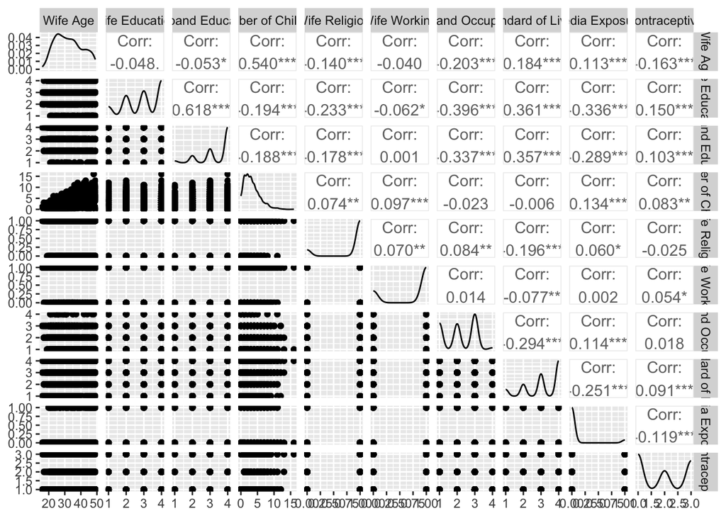

From the correlation matrix, number of children and wife’s age has high positive correlation (0.54) as well as husband education and wife education (0.62).

#### Variable Assessment

The distribution of wife’s age is not normal so I centralized it for easier interpretation (wife_age.c).

Wife’s Age and Number of Children are discrete variables. The rest are categorical or binary variables so I factored these variables. For easier analysis, I changed the factoring of contraceptive method so that short term (2) and long term (3) are in one category.

| Var1 | Freq |
| --- | --- |
| 0 | 0.4270197 |
| 1 | 0.5729803 |

At a highlevel, in the sample 42% do not use contraceptive methods while 57% of woman do.

### Table 2: Individual Relationships, Standard Errors, 95% CI, p-values

#### 1. Wife Age vs Contraceptive

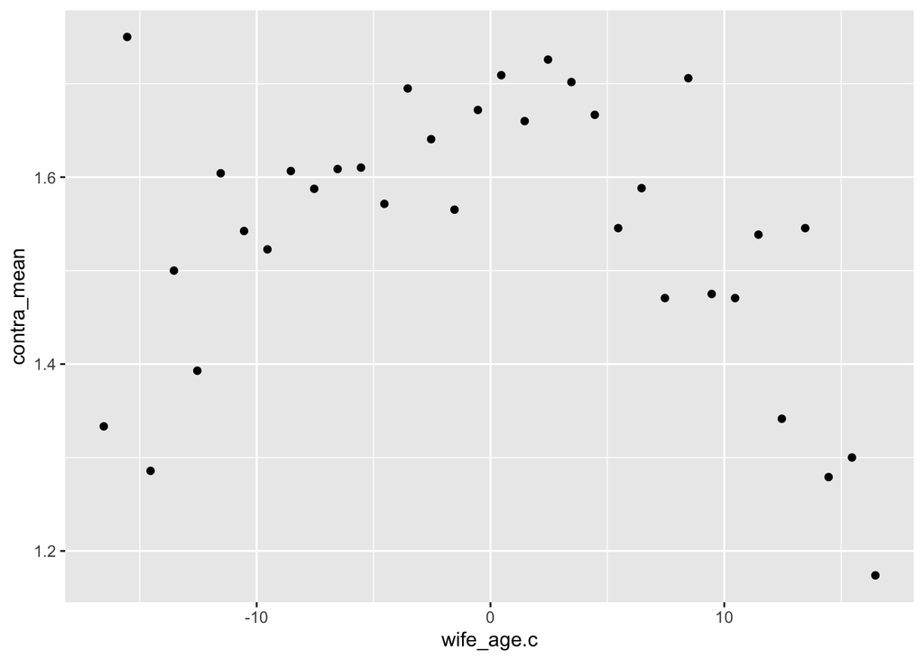

Before modeling, I assessed the linearity of wife’s age using MFP.

MFP suggests I(wife_age.c<sup>2</sup>) + I(wife_age.c<sup>3</sup>) transformation.

|  | contra.f |  |  |  | contra.f |  |  |  |
| --- | --- | --- | --- | --- | --- | --- | --- | --- |
| Predictors | Odds Ratios | std. Error | CI | p | Odds Ratios | std. Error | CI | p |
| (Intercept) | 1.35 | 0.07 | 1.21 – 1.49 | **<0.001** | 1.96 | 0.15 | 1.69 – 2.29 | **<0.001** |
| wife age c | 0.98 | 0.01 | 0.97 – 0.99 | **<0.001** | 1.01 | 0.01 | 0.98 – 1.04 | 0.417 |
| wife age c^2 |  |  |  |  | 0.99 | 0.00 | 0.99 – 1.00 | **<0.001** |
| wife age c^3 |  |  |  |  | 1.00 | 0.00 | 1.00 – 1.00 | 0.074 |
| Observations | 1473 |  |  |  | 1473 |  |  |  |
| R<sup>2</sup> Tjur | 0.009 |  |  |  | 0.045 |  |  |  |
| AIC | 2001.765 |  |  |  | 1952.239 |  |  |  |

After transformation, wife_age.c and wife_age.c<sup>3</sup> are no longer significant. Based off the earlier plot, I think a squared transformation of wife_age.c would suffice.

#### 2. Wife Education vs Contraceptive

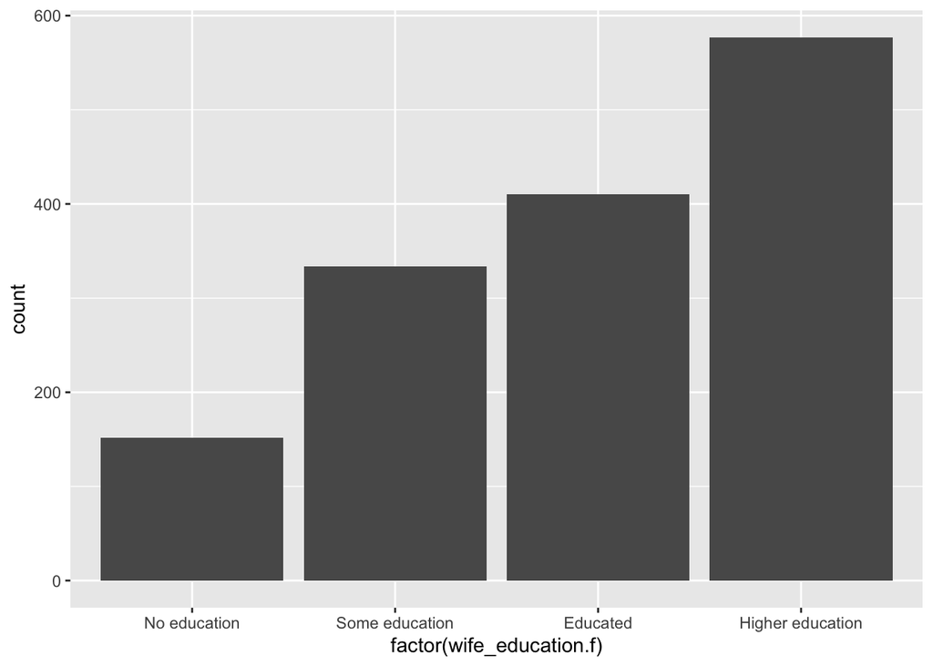

|  | 0 | 1 |
| --- | --- | --- |
| No education | 103 | 49 |
| Some education | 176 | 158 |
| Educated | 175 | 235 |
| Higher education | 175 | 402 |

From the bar chart, there are more woman that have education that those that have little to none. The table shows woman with minimal education mostly do not use contraceptive methods while woman with higher education mostly do use.

|  | contra.f |  |  |  |
| --- | --- | --- | --- | --- |
| Predictors | Odds Ratios | std. Error | CI | p |
| (Intercept) | 0.48 | 0.08 | 0.34 – 0.66 | **<0.001** |
| wife education f [Some education] | 1.89 | 0.39 | 1.27 – 2.84 | **0.002** |
| wife education f [Educated] | 2.82 | 0.57 | 1.92 – 4.20 | **<0.001** |
| wife education f [Higher education] | 4.83 | 0.95 | 3.31 – 7.13 | **<0.001** |
| Observations | 1473 |  |  |  |
| R<sup>2</sup> Tjur | 0.060 |  |  |  |
| AIC | 1928.855 |  |  |  |

Wife’s education is statistically related to contraceptive use.

#### 3. Husband Education vs Contraceptive

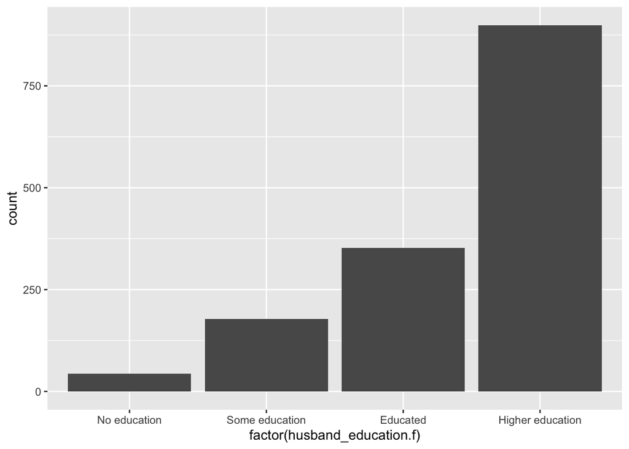

|  | 0 | 1 |
| --- | --- | --- |
| No education | 31 | 13 |
| Some education | 99 | 79 |
| Educated | 161 | 191 |
| Higher education | 338 | 561 |

The barchart show significantly more men with higher education in the sample. Men with higher education have wives that are more likely to use contraception.

|  | contra.f |  |  |  |
| --- | --- | --- | --- | --- |
| Predictors | Odds Ratios | std. Error | CI | p |
| (Intercept) | 0.42 | 0.14 | 0.21 – 0.78 | **0.009** |
| husband education f [Some education] | 1.90 | 0.69 | 0.95 – 3.99 | 0.077 |
| husband education f [Educated] | 2.83 | 0.98 | 1.46 – 5.77 | **0.003** |
| husband education f [Higher education] | 3.96 | 1.34 | 2.09 – 7.93 | **<0.001** |
| Observations | 1473 |  |  |  |
| R<sup>2</sup> Tjur | 0.025 |  |  |  |
| AIC | 1981.718 |  |  |  |

Husband’s education is statistically related to contraceptive use.

#### 4. Number of Children vs Contraceptive

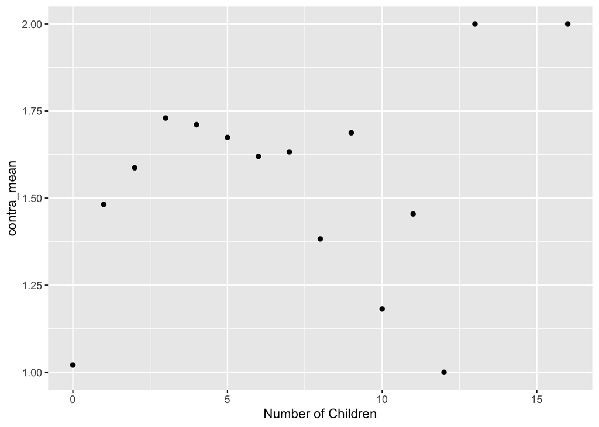

Before modeling, I assessed the linearity of number of children using MFP.

The MFP results showed linear form of number of children is fine.

|  | contra.f |  |  |  |
| --- | --- | --- | --- | --- |
| Predictors | Odds Ratios | std. Error | CI | p |
| (Intercept) | 0.95 | 0.09 | 0.80 – 1.14 | 0.594 |
| Number of Children | 1.11 | 0.03 | 1.06 – 1.17 | **<0.001** |
| Observations | 1473 |  |  |  |
| R<sup>2</sup> Tjur | 0.015 |  |  |  |
| AIC | 1992.951 |  |  |  |

#### 5. Wife Religion vs Contraceptive

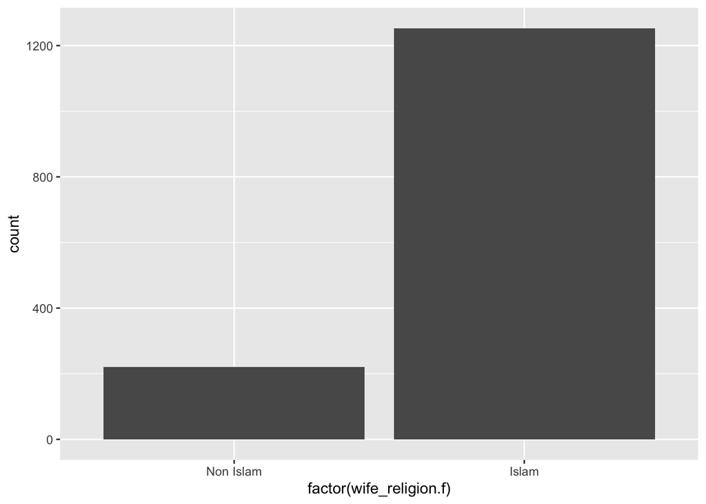

|  | 0 | 1 |
| --- | --- | --- |
| Non Islam | 75 | 145 |
| Islam | 554 | 699 |

The barchart shows that most of the woman in the sample are Muslim. Solely based of the table, more woman use contraception regardless of religion.

|  | contra.f |  |  |  |
| --- | --- | --- | --- | --- |
| Predictors | Odds Ratios | std. Error | CI | p |
| (Intercept) | 1.93 | 0.27 | 1.47 – 2.57 | **<0.001** |
| wife religion f [Islam] | 0.65 | 0.10 | 0.48 – 0.88 | **0.005** |
| Observations | 1473 |  |  |  |
| R<sup>2</sup> Tjur | 0.005 |  |  |  |
| AIC | 2006.530 |  |  |  |

Wife’s religion is statistically related to contraceptive use.

#### 6. Wife Working vs Contraceptive

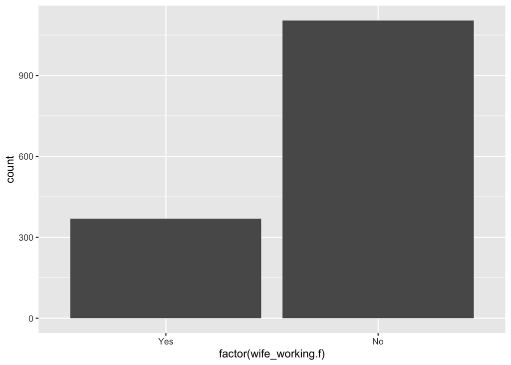

|  | 0 | 1 |
| --- | --- | --- |
| Yes | 170 | 199 |
| No | 459 | 645 |

|  | contra.f |  |  |  |
| --- | --- | --- | --- | --- |
| Predictors | Odds Ratios | std. Error | CI | p |
| (Intercept) | 1.17 | 0.12 | 0.95 – 1.44 | 0.132 |
| wife working f [No] | 1.20 | 0.15 | 0.95 – 1.52 | 0.131 |
| Observations | 1473 |  |  |  |
| R<sup>2</sup> Tjur | 0.002 |  |  |  |
| AIC | 2012.243 |  |  |  |

Wife working is not statistically significant to contraceptive use. This will be excluded from final model.

#### 7. Husband Occupation vs Contraceptive

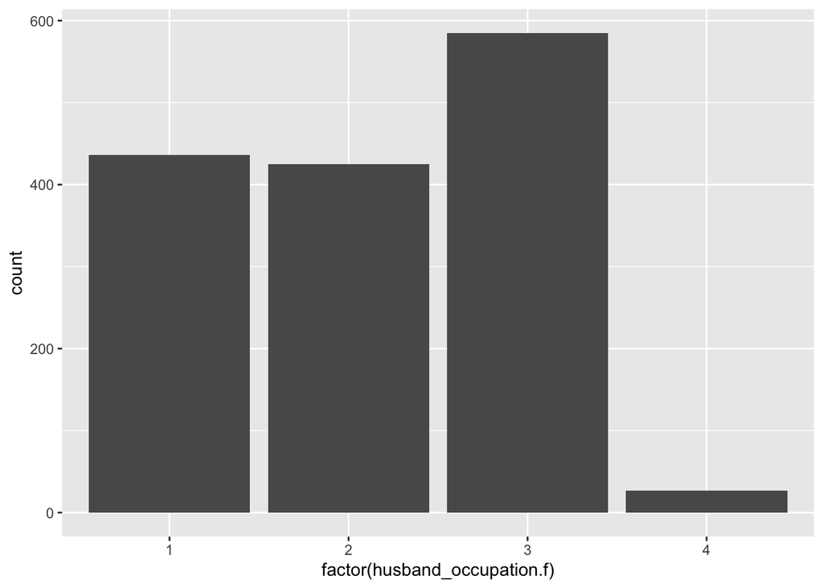

| 0 | 1 |
| --- | --- |
| 158 | 278 |
| 200 | 225 |
| 258 | 327 |
| 13 | 14 |

|  | contra.f |  |  |  |
| --- | --- | --- | --- | --- |
| Predictors | Odds Ratios | std. Error | CI | p |
| (Intercept) | 1.76 | 0.18 | 1.45 – 2.14 | **<0.001** |
| husband occupation f [2] | 0.64 | 0.09 | 0.49 – 0.84 | **0.001** |
| husband occupation f [3] | 0.72 | 0.09 | 0.56 – 0.93 | **0.012** |
| husband occupation f [4] | 0.61 | 0.24 | 0.28 – 1.35 | 0.217 |
| Observations | 1473 |  |  |  |
| R<sup>2</sup> Tjur | 0.008 |  |  |  |
| AIC | 2006.888 |  |  |  |

#### 8. Standard of Living vs Contraceptive

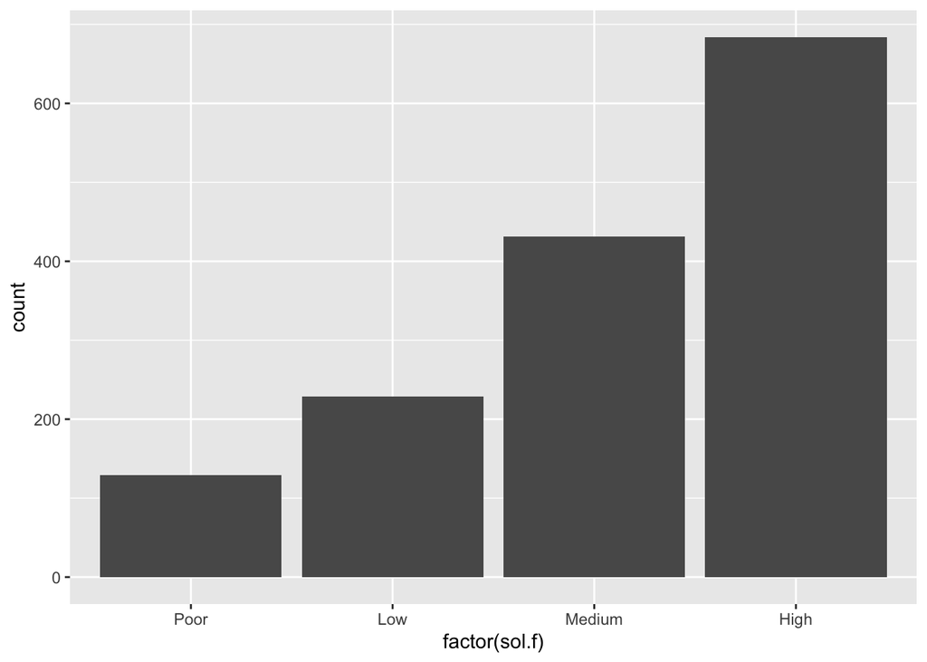

|  | 0 | 1 |
| --- | --- | --- |
| Poor | 80 | 49 |
| Low | 117 | 112 |
| Medium | 184 | 247 |
| High | 248 | 436 |

More women in the sample have a high standard of living. Those with low or poor are do not use contraception more than those with medium or high standard of living.

|  | contra.f |  |  |  |
| --- | --- | --- | --- | --- |
| Predictors | Odds Ratios | std. Error | CI | p |
| (Intercept) | 0.61 | 0.11 | 0.43 – 0.87 | **0.007** |
| sol f [Low] | 1.56 | 0.35 | 1.01 – 2.44 | **0.047** |
| sol f [Medium] | 2.19 | 0.45 | 1.47 – 3.30 | **<0.001** |
| sol f [High] | 2.87 | 0.57 | 1.95 – 4.25 | **<0.001** |
| Observations | 1473 |  |  |  |
| R<sup>2</sup> Tjur | 0.026 |  |  |  |
| AIC | 1980.794 |  |  |  |

Standard of living is statistically related to contraception use.

#### 9. Media Exposure vs Contraceptive

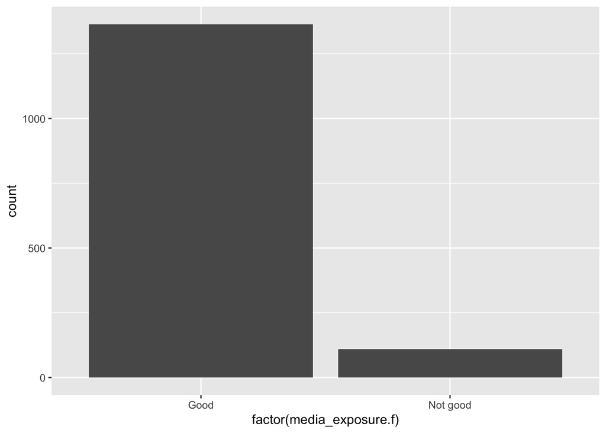

|  | 0 | 1 |
| --- | --- | --- |
| Good | 555 | 809 |
| Not good | 74 | 35 |

The sample of woman mostly have good media exposure. Those with good media exposure use contraception more. Those with not good media exposure do not use contraception as much.

Media exposure is statistically related to contraceptive use.

|  | contra.f |  |  |  |
| --- | --- | --- | --- | --- |
| Predictors | Odds Ratios | std. Error | CI | p |
| (Intercept) | 1.46 | 0.08 | 1.31 – 1.62 | **<0.001** |
| media exposure f [Not good] | 0.32 | 0.07 | 0.21 – 0.49 | **<0.001** |
| Observations | 1473 |  |  |  |
| R<sup>2</sup> Tjur | 0.021 |  |  |  |
| AIC | 1984.167 |  |  |  |

Media exposure is statistically related to contraceptive use.

### Table 3: Final Model Selection, Confounding/Effect Modification, Diagnostics

I wanted to run a model with all variables and no transformation (all_model) to see how it compares to the other model where I performed variable selection by univariate analysis (test_model).

#### Model Selection

**Model with all predictors versus Model with selected predictors and transformation**

|  | contra.f |  |  | contra.f |  |  |
| --- | --- | --- | --- | --- | --- | --- |
| Predictors | Odds Ratios | CI | p | Odds Ratios | CI | p |
| (Intercept) | 0.10 | 0.04 – 0.28 | **<0.001** | 0.26 | 0.10 – 0.65 | **0.004** |
| wife age c | 0.92 | 0.90 – 0.94 | **<0.001** |  |  |  |
| wife education f [Some education] | 1.38 | 0.86 – 2.22 | 0.184 | 1.55 | 0.98 – 2.44 | 0.060 |
| wife education f [Educated] | 2.18 | 1.33 – 3.59 | **0.002** | 2.45 | 1.54 – 3.95 | **<0.001** |
| wife education f [Higher education] | 4.67 | 2.74 – 8.03 | **<0.001** | 4.28 | 2.59 – 7.11 | **<0.001** |
| husband education f [Some education] | 1.38 | 0.64 – 3.09 | 0.425 | 1.47 | 0.69 – 3.24 | 0.323 |
| husband education f [Educated] | 1.56 | 0.73 – 3.44 | 0.260 | 1.57 | 0.75 – 3.39 | 0.241 |
| husband education f [Higher education] | 1.31 | 0.61 – 2.92 | 0.500 | 1.34 | 0.64 – 2.93 | 0.449 |
| Number of Children | 1.41 | 1.32 – 1.52 | **<0.001** | 1.19 | 1.14 – 1.26 | **<0.001** |
| wife religion f [Islam] | 0.64 | 0.45 – 0.90 | **0.011** | 0.94 | 0.68 – 1.30 | 0.714 |
| wife working f [No] | 1.14 | 0.88 – 1.49 | 0.312 |  |  |  |
| husband occupation f [2] | 0.83 | 0.59 – 1.15 | 0.251 |  |  |  |
| husband occupation f [3] | 1.08 | 0.78 – 1.49 | 0.656 |  |  |  |
| husband occupation f [4] | 1.64 | 0.67 – 4.02 | 0.277 |  |  |  |
| sol f [Low] | 1.50 | 0.94 – 2.42 | 0.094 | 1.22 | 0.77 – 1.97 | 0.398 |
| sol f [Medium] | 1.77 | 1.13 – 2.79 | **0.013** | 1.37 | 0.88 – 2.14 | 0.166 |
| sol f [High] | 2.28 | 1.45 – 3.61 | **<0.001** | 1.50 | 0.97 – 2.34 | 0.069 |
| media exposure f [Not good] | 0.58 | 0.35 – 0.96 | **0.036** | 0.53 | 0.33 – 0.87 | **0.012** |
| wife age c^2 |  |  |  | 0.99 | 0.99 – 1.00 | **<0.001** |
| Observations | 1473 |  |  | 1473 |  |  |
| R<sup>2</sup> Tjur | 0.159 |  |  | 0.133 |  |  |
| AIC | 1798.618 |  |  | 24740.310 |  |  |

Even after examining the predictors independently, the model with that selection and transformation of wife_age.c<sup>2</sup> is worse than the model with all the predictors. The AIC of the full model is 1798 while the test model is 24740.

**Model with all predictors versus Model with with selected predictors (no age transformation)**

|  | contra.f |  |  | contra.f |  |  |
| --- | --- | --- | --- | --- | --- | --- |
| Predictors | Odds Ratios | CI | p | Odds Ratios | CI | p |
| (Intercept) | 0.10 | 0.04 – 0.28 | **<0.001** | 0.15 | 0.08 – 0.30 | **<0.001** |
| wife age c | 0.92 | 0.90 – 0.94 | **<0.001** | 0.92 | 0.90 – 0.94 | **<0.001** |
| wife education f [Some education] | 1.38 | 0.86 – 2.22 | 0.184 | 1.40 | 0.88 – 2.23 | 0.155 |
| wife education f [Educated] | 2.18 | 1.33 – 3.59 | **0.002** | 2.15 | 1.36 – 3.43 | **0.001** |
| wife education f [Higher education] | 4.67 | 2.74 – 8.03 | **<0.001** | 4.36 | 2.74 – 7.01 | **<0.001** |
| husband education f [Some education] | 1.38 | 0.64 – 3.09 | 0.425 |  |  |  |
| husband education f [Educated] | 1.56 | 0.73 – 3.44 | 0.260 |  |  |  |
| husband education f [Higher education] | 1.31 | 0.61 – 2.92 | 0.500 |  |  |  |
| Number of Children | 1.41 | 1.32 – 1.52 | **<0.001** | 1.41 | 1.32 – 1.51 | **<0.001** |
| wife religion f [Islam] | 0.64 | 0.45 – 0.90 | **0.011** | 0.67 | 0.48 – 0.93 | **0.019** |
| wife working f [No] | 1.14 | 0.88 – 1.49 | 0.312 |  |  |  |
| husband occupation f [2] | 0.83 | 0.59 – 1.15 | 0.251 |  |  |  |
| husband occupation f [3] | 1.08 | 0.78 – 1.49 | 0.656 |  |  |  |
| husband occupation f [4] | 1.64 | 0.67 – 4.02 | 0.277 |  |  |  |
| sol f [Low] | 1.50 | 0.94 – 2.42 | 0.094 | 1.48 | 0.93 – 2.38 | 0.102 |
| sol f [Medium] | 1.77 | 1.13 – 2.79 | **0.013** | 1.74 | 1.12 – 2.73 | **0.014** |
| sol f [High] | 2.28 | 1.45 – 3.61 | **<0.001** | 2.22 | 1.43 – 3.49 | **<0.001** |
| media exposure f [Not good] | 0.58 | 0.35 – 0.96 | **0.036** | 0.57 | 0.35 – 0.94 | **0.029** |
| Observations | 1473 |  |  | 1473 |  |  |
| R<sup>2</sup> Tjur | 0.159 |  |  | 0.154 |  |  |
| AIC | 1798.618 |  |  | 1792.611 |  |  |

I performed another model with the linear term of wife_age.c instead of squared and the AIC is now 1792. Before I finalized my model, I observed confounding and effect modifiers.

#### Examining demographic confounding

The criteria for confounding is at least a 10% change in estimates and variables must be sensibly a cause to both X and Y.

#### 1. Wife’s Age

**Model without wife’s age versus with wife’s age**

|  | contra.f |  |  | contra.f |  |  |
| --- | --- | --- | --- | --- | --- | --- |
| Predictors | Odds Ratios | CI | p | Odds Ratios | CI | p |
| (Intercept) | 0.22 | 0.11 – 0.42 | **<0.001** | 0.15 | 0.08 – 0.30 | **<0.001** |
| wife education f [Some education] | 1.90 | 1.23 – 2.95 | **0.004** | 1.40 | 0.88 – 2.23 | 0.155 |
| wife education f [Educated] | 2.85 | 1.85 – 4.42 | **<0.001** | 2.15 | 1.36 – 3.43 | **0.001** |
| wife education f [Higher education] | 4.78 | 3.07 – 7.52 | **<0.001** | 4.36 | 2.74 – 7.01 | **<0.001** |
| Number of Children | 1.19 | 1.13 – 1.25 | **<0.001** | 1.41 | 1.32 – 1.51 | **<0.001** |
| wife religion f [Islam] | 0.90 | 0.65 – 1.23 | 0.506 | 0.67 | 0.48 – 0.93 | **0.019** |
| sol f [Low] | 1.31 | 0.83 – 2.08 | 0.247 | 1.48 | 0.93 – 2.38 | 0.102 |
| sol f [Medium] | 1.45 | 0.94 – 2.23 | 0.091 | 1.74 | 1.12 – 2.73 | **0.014** |
| sol f [High] | 1.55 | 1.02 – 2.39 | **0.043** | 2.22 | 1.43 – 3.49 | **<0.001** |
| media exposure f [Not good] | 0.54 | 0.33 – 0.86 | **0.010** | 0.57 | 0.35 – 0.94 | **0.029** |
| wife age c |  |  |  | 0.92 | 0.90 – 0.94 | **<0.001** |
| Observations | 1473 |  |  | 1473 |  |  |
| R<sup>2</sup> Tjur | 0.100 |  |  | 0.154 |  |  |
| AIC | 1879.097 |  |  | 1792.611 |  |  |

The are multiple beta % changes when wife’s age is added to the model. Wife’s age is a confounder.

#### 2. Wife’s Education

**Model without wife’s education versus with wife’s education**

|  | contra.f |  |  | contra.f |  |  |
| --- | --- | --- | --- | --- | --- | --- |
| Predictors | Odds Ratios | CI | p | Odds Ratios | CI | p |
| (Intercept) | 0.39 | 0.23 – 0.65 | **<0.001** | 0.15 | 0.08 – 0.30 | **<0.001** |
| wife age c | 0.92 | 0.91 – 0.94 | **<0.001** | 0.92 | 0.90 – 0.94 | **<0.001** |
| Number of Children | 1.34 | 1.26 – 1.43 | **<0.001** | 1.41 | 1.32 – 1.51 | **<0.001** |
| wife religion f [Islam] | 0.55 | 0.39 – 0.76 | **<0.001** | 0.67 | 0.48 – 0.93 | **0.019** |
| sol f [Low] | 1.68 | 1.06 – 2.68 | **0.027** | 1.48 | 0.93 – 2.38 | 0.102 |
| sol f [Medium] | 2.27 | 1.48 – 3.51 | **<0.001** | 1.74 | 1.12 – 2.73 | **0.014** |
| sol f [High] | 3.39 | 2.22 – 5.21 | **<0.001** | 2.22 | 1.43 – 3.49 | **<0.001** |
| media exposure f [Not good] | 0.39 | 0.25 – 0.62 | **<0.001** | 0.57 | 0.35 – 0.94 | **0.029** |
| wife education f [Some education] |  |  |  | 1.40 | 0.88 – 2.23 | 0.155 |
| wife education f [Educated] |  |  |  | 2.15 | 1.36 – 3.43 | **0.001** |
| wife education f [Higher education] |  |  |  | 4.36 | 2.74 – 7.01 | **<0.001** |
| Observations | 1473 |  |  | 1473 |  |  |
| R<sup>2</sup> Tjur | 0.114 |  |  | 0.154 |  |  |
| AIC | 1853.948 |  |  | 1792.611 |  |  |

The are multiple beta % changes when wife’s education is added to the model. Wife’s education is a confounder.

#### 3. Number of Children

**Model without number of children versus with number of children**

|  | contra.f |  |  | contra.f |  |  |
| --- | --- | --- | --- | --- | --- | --- |
| Predictors | Odds Ratios | CI | p | Odds Ratios | CI | p |
| (Intercept) | 0.46 | 0.25 – 0.84 | **0.013** | 0.15 | 0.08 – 0.30 | **<0.001** |
| wife age c | 0.97 | 0.96 – 0.99 | **<0.001** | 0.92 | 0.90 – 0.94 | **<0.001** |
| wife education f [Some education] | 1.40 | 0.91 – 2.16 | 0.128 | 1.40 | 0.88 – 2.23 | 0.155 |
| wife education f [Educated] | 1.95 | 1.27 – 3.01 | **0.002** | 2.15 | 1.36 – 3.43 | **0.001** |
| wife education f [Higher education] | 3.10 | 2.02 – 4.80 | **<0.001** | 4.36 | 2.74 – 7.01 | **<0.001** |
| wife religion f [Islam] | 0.86 | 0.62 – 1.19 | 0.370 | 0.67 | 0.48 – 0.93 | **0.019** |
| sol f [Low] | 1.44 | 0.92 – 2.28 | 0.117 | 1.48 | 0.93 – 2.38 | 0.102 |
| sol f [Medium] | 1.72 | 1.12 – 2.65 | **0.013** | 1.74 | 1.12 – 2.73 | **0.014** |
| sol f [High] | 2.00 | 1.30 – 3.08 | **0.002** | 2.22 | 1.43 – 3.49 | **<0.001** |
| media exposure f [Not good] | 0.67 | 0.42 – 1.06 | 0.093 | 0.57 | 0.35 – 0.94 | **0.029** |
| Number of Children |  |  |  | 1.41 | 1.32 – 1.51 | **<0.001** |
| Observations | 1473 |  |  | 1473 |  |  |
| R<sup>2</sup> Tjur | 0.079 |  |  | 0.154 |  |  |
| AIC | 1912.478 |  |  | 1792.611 |  |  |

The are multiple beta % changes when number of children is added to the model. Number of children is a confounder.

#### 4. Number of Religion

**Model without wife’s religion versus without wife’s religion**

|  | contra.f |  |  | contra.f |  |  |
| --- | --- | --- | --- | --- | --- | --- |
| Predictors | Odds Ratios | CI | p | Odds Ratios | CI | p |
| (Intercept) | 0.10 | 0.06 – 0.19 | **<0.001** | 0.15 | 0.08 – 0.30 | **<0.001** |
| wife age c | 0.92 | 0.91 – 0.94 | **<0.001** | 0.92 | 0.90 – 0.94 | **<0.001** |
| wife education f [Some education] | 1.45 | 0.91 – 2.30 | 0.116 | 1.40 | 0.88 – 2.23 | 0.155 |
| wife education f [Educated] | 2.27 | 1.44 – 3.60 | **<0.001** | 2.15 | 1.36 – 3.43 | **0.001** |
| wife education f [Higher education] | 4.71 | 2.97 – 7.53 | **<0.001** | 4.36 | 2.74 – 7.01 | **<0.001** |
| Number of Children | 1.40 | 1.31 – 1.50 | **<0.001** | 1.41 | 1.32 – 1.51 | **<0.001** |
| sol f [Low] | 1.48 | 0.93 – 2.38 | 0.100 | 1.48 | 0.93 – 2.38 | 0.102 |
| sol f [Medium] | 1.75 | 1.13 – 2.74 | **0.013** | 1.74 | 1.12 – 2.73 | **0.014** |
| sol f [High] | 2.30 | 1.48 – 3.60 | **<0.001** | 2.22 | 1.43 – 3.49 | **<0.001** |
| media exposure f [Not good] | 0.59 | 0.35 – 0.96 | **0.034** | 0.57 | 0.35 – 0.94 | **0.029** |
| wife religion f [Islam] |  |  |  | 0.67 | 0.48 – 0.93 | **0.019** |
| Observations | 1473 |  |  | 1473 |  |  |
| R<sup>2</sup> Tjur | 0.151 |  |  | 0.154 |  |  |
| AIC | 1796.203 |  |  | 1792.611 |  |  |

Wife’s religion does not heavily impact beta coefficients. It is not a confounder but is it significant in our model.

#### Examining effect modification

|  | contra.f |  |  | contra.f |  |  |
| --- | --- | --- | --- | --- | --- | --- |
| Predictors | Odds Ratios | CI | p | Odds Ratios | CI | p |
| (Intercept) | 0.14 | 0.07 – 0.28 | **<0.001** | 0.15 | 0.08 – 0.30 | **<0.001** |
| wife age c | 0.98 | 0.95 – 1.00 | 0.077 | 0.92 | 0.90 – 0.94 | **<0.001** |
| wife education f [Some education] | 1.24 | 0.77 – 2.00 | 0.379 | 1.40 | 0.88 – 2.23 | 0.155 |
| wife education f [Educated] | 2.04 | 1.28 – 3.28 | **0.003** | 2.15 | 1.36 – 3.43 | **0.001** |
| wife education f [Higher education] | 4.28 | 2.67 – 6.94 | **<0.001** | 4.36 | 2.74 – 7.01 | **<0.001** |
| Number of Children | 1.61 | 1.49 – 1.74 | **<0.001** | 1.41 | 1.32 – 1.51 | **<0.001** |
| wife religion f [Islam] | 0.69 | 0.49 – 0.97 | **0.035** | 0.67 | 0.48 – 0.93 | **0.019** |
| sol f [Low] | 1.44 | 0.88 – 2.36 | 0.145 | 1.48 | 0.93 – 2.38 | 0.102 |
| sol f [Medium] | 1.63 | 1.03 – 2.60 | **0.038** | 1.74 | 1.12 – 2.73 | **0.014** |
| sol f [High] | 2.10 | 1.32 – 3.36 | **0.002** | 2.22 | 1.43 – 3.49 | **<0.001** |
| media exposure f [Not good] | 0.55 | 0.32 – 0.91 | **0.020** | 0.57 | 0.35 – 0.94 | **0.029** |
| wife age c * Number of Children | 0.98 | 0.97 – 0.98 | **<0.001** |  |  |  |
| Observations | 1473 |  |  | 1473 |  |  |
| R<sup>2</sup> Tjur | 0.191 |  |  | 0.154 |  |  |
| AIC | 1738.344 |  |  | 1792.611 |  |  |

I observed the interaction effect between wife’s age and number of children because of the correlation matrix. The interaction term is significant in the model. The model with the interaction is shown to have a lower AIC than the model with only selected predictors and no transformation (1738 vs 1792). I selected the model with the interaction as my final model.

#### Diagnostics

**Multicollinearity**

```
##                                     GVIF Df GVIF^(1/(2*Df))
## wife_age.c                      3.105538  1        1.762254
## wife_education.f                1.469883  3        1.066303
## `Number of Children`            2.407625  1        1.551652
## wife_religion.f                 1.113222  1        1.055094
## sol.f                           1.307786  3        1.045738
## media_exposure.f                1.206861  1        1.098572
## wife_age.c:`Number of Children` 4.018115  1        2.004524
```

There is no evidence of multicollinearity in the model.

**McFadden R Squared**

```
##  McFadden
## 0.1473122
```

According to McFadden, these predictors explain approximately 14.7% of the variation in contraceptive use.

**Homer-Lemeshow GOF**

```
##
##  Hosmer and Lemeshow goodness of fit (GOF) test
##
## data:  withint2_model$y, fitted(withint2_model)
## X-squared = 22.081, df = 8, p-value = 0.004768
```

After running the GOF test, there is evidence of lack of fit (p = ~0.00).

**Influential**

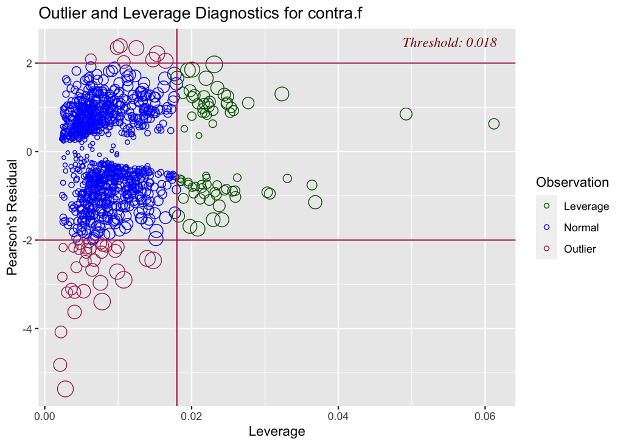

There are no observations with significant influence and leverage.

# **Interpretation and Conclusion**

A one unit increase in wife’s age is associated with 0.98 times the odds of contraceptive use. A one unit increase in number of children is associated with 1.61 times the odds of contraceptive use. A woman with higher education is associated with 4.28 times the odds than a woman with no education. A woman with a high standard of living index is associated with 2.1 times the odds than a woman with poor standard of living.

Overall, a woman’s age, education, religion, current number of children, standard of living, and media exposure can predict contraceptive use. From the diagnostics ran, the model can use improvement in terms of model fit but there is no influential data points.